# In-Class Regression Work

Alan T. Arnholt

Last compiled: Thursday, September 10, 2020 - 03:07:24 PM.

# 1 Apartments in Vitoria

Making a new factor variable for elevators named `elevatorF`.

```r
VIT2005 <- VIT2005 %>%
  mutate(elevatorF = as.factor(elevator)) %>%
  glimpse()
```

```
Rows: 218
Columns: 16
$ totalprice     <dbl> 228000.0, 409000.0, 200000.0, 180000.0, 443600.0, 1730…
$ area           <dbl> 75.31, 100.65, 88.87, 62.61, 146.15, 77.21, 77.04, 62.…
$ zone           <fct> Z45, Z31, Z52, Z62, Z31, Z11, Z47, Z48, Z11, Z11, Z37,…
$ category       <fct> 4B, 3B, 3A, 4A, 3A, 4B, 3A, 3B, 4B, 3B, 4B, 4B, 2B, 4B…
$ age            <int> 33, 5, 14, 41, 22, 35, 14, 36, 37, 11, 36, 10, 7, 9, 1…
$ floor          <int> 3, 7, 8, 3, 6, 4, 6, 3, 4, 5, 6, 3, 4, 2, 6, 4, 4, 4, …
$ rooms          <int> 5, 5, 5, 4, 7, 5, 4, 4, 4, 4, 6, 5, 6, 5, 5, 4, 4, 5, …
$ out            <fct> E100, E50, E50, E50, E100, E50, E50, E100, E25, E50, E…
$ conservation   <fct> 2B, 1A, 1A, 2A, 1A, 1A, 1A, 3A, 2A, 1A, 2B, 1A, 1A, 1A…
$ toilets        <int> 1, 2, 2, 1, 2, 1, 1, 1, 1, 1, 2, 1, 2, 1, 1, 1, 1, 1, …
$ garage         <int> 0, 1, 0, 0, 0, 0, 0, 0, 0, 0, 0, 0, 1, 0, 0, 0, 0, 0, …
$ elevator       <int> 1, 1, 1, 0, 1, 0, 1, 0, 0, 0, 1, 0, 1, 1, 1, 0, 0, 1, …
$ streetcategory <fct> S3, S5, S2, S3, S4, S4, S3, S3, S4, S4, S2, S3, S4, S4…
$ heating        <fct> 3A, 4A, 3A, 1A, 4A, 3A, 4A, 3A, 3A, 3A, 4A, 3A, 3B, 3A…
$ storage        <int> 0, 1, 0, 0, 1, 1, 1, 1, 1, 1, 1, 1, 1, 1, 1, 0, 1, 1, …
$ elevatorF      <fct> 1, 1, 1, 0, 1, 0, 1, 0, 0, 0, 1, 0, 1, 1, 1, 0, 0, 1, …
```

## 1.1 Exercise

- Create a scatterplot of `totalprice` versus `area`.

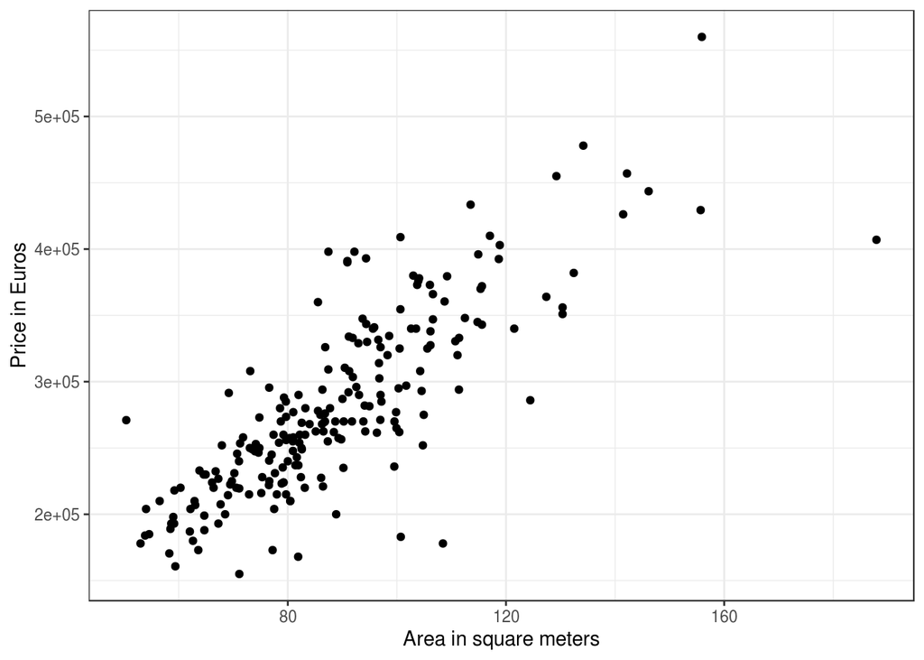

```r
ggplot(data = VIT2005, aes(x = area, y = totalprice)) +
  geom_point() +
  theme_bw() +
  labs(x = "Area in square meters", y = "Price in Euros")
```

To refer to the Figure 1.1, use the syntax `\@ref(fig:label)`.

- Compute $r$ using the formula given in (1.1) and verify your answer using the built-in R function `cor()`.

$$\begin{equation}
r = \frac{1}{n-1}\sum_{i=1}^{n}\left(\frac{x_i - \bar{x}}{s_x}\right)\cdot\left(\frac{y_i - \bar{y}}{s_y}\right)
\tag{1.1}
\end{equation}$$

```r
values <- VIT2005 %>%
  mutate(x_xbar = area - mean(area), y_ybar = totalprice - mean(totalprice),
         zx = x_xbar/sd(area), zy  = y_ybar/sd(totalprice)) %>%
  select(area, x_xbar, zx, totalprice, y_ybar, zy)
head(values)
```

```
    area      x_xbar           zx totalprice     y_ybar         zy
1  75.31 -13.3928463 -0.645972464     228000  -52741.52 -0.7610779
2 100.65  11.9471576  0.576243069     409000  128258.48  1.8508128
3  88.87   0.1671589  0.008062516     200000  -80741.52 -1.1651273
4  62.61 -26.0928433 -1.258526968     180000 -100741.52 -1.4537340
5 146.15  57.4471500  2.770828263     443600  162858.48  2.3501024
6  77.21 -11.4928448 -0.554330357     173000 -107741.52 -1.5547463
```

```r
values %>%
  summarize(r = sum(zx*zy)/(length(zx) - 1))
```

```
          r
1 0.8092125
```

```r
#
#  Built In Function
VIT2005 %>%
  summarize(r = cor(totalprice, area))
```

```
          r
1 0.8092125
```

- Create a linear model object named `mod1` by regressing `totalprice` on to `area`.

```r
mod1 <- lm(totalprice ~ area, data = VIT2005)
mod1
```

```
Call:
lm(formula = totalprice ~ area, data = VIT2005)

Coefficients:
(Intercept)         area
      40822         2705
```

- Write the least squares regression equation.

$$\widehat{\text{totalprice}} = 4.0822416\times 10^{4} + 2704.7510279\cdot \text{area}$$

- Use the coefficients from `mod1` and `mutate()` to compute the $\hat{y}$ and $e_i$ values.

```r
values <- VIT2005 %>%
  mutate(yhat = coef(mod1)[1] + coef(mod1)[2]*area,
         e = totalprice - yhat) %>%
  select(totalprice, yhat, area, e)
head(values)
```

```
  totalprice     yhat   area          e
1     228000 244517.2  75.31 -16517.209
2     409000 313055.6 100.65  95944.389
3     200000 281193.6  88.87 -81193.647
4     180000 210166.9  62.61 -30166.879
5     443600 436121.8 146.15   7478.238
6     173000 249656.2  77.21 -76656.240
```

```r
# Or
values <- VIT2005 %>%
  mutate(yhat = predict(mod1), e = resid(mod1)) %>%
  select(totalprice, yhat, area, e)
head(values)
```

```
  totalprice     yhat   area          e
1     228000 244517.2  75.31 -16517.209
2     409000 313055.6 100.65  95944.389
3     200000 281193.6  88.87 -81193.647
4     180000 210166.9  62.61 -30166.879
5     443600 436121.8 146.15   7478.238
6     173000 249656.2  77.21 -76656.240
```

- Find the least squares coeffients for regressing `totalprice` on to `area` using the formulas below.

$$b_1 = r\cdot\frac{s_y}{s_x}$$
$$b_0 = \bar{y} - b_1\cdot\bar{x}$$

```r
VIT2005 %>%
  summarize(r = cor(totalprice, area),
            b1 = r*sd(totalprice)/sd(area),
            b0 = mean(totalprice) - b1*mean(area))
```

```
          r       b1       b0
1 0.8092125 2704.751 40822.42
```

- Print the least squares coefficients for `mod1` using `get_regression_table()`.

```r
CT <- get_regression_table(mod1)
CT
```

```
# A tibble: 2 x 7
  term      estimate std_error statistic p_value lower_ci upper_ci
  <chr>        <dbl>     <dbl>     <dbl>   <dbl>    <dbl>    <dbl>
1 intercept   40822.    12170.      3.35   0.001   16835.   64810.
2 area         2705.      134.     20.2    0        2441.    2968.
```

```r
CT[1, 2]
```

```
# A tibble: 1 x 1
  estimate
     <dbl>
1   40822.
```

```r
CT[2, 2]
```

```
# A tibble: 1 x 1
  estimate
     <dbl>
1    2705.
```

## 1.2 Exercise

- Create the linear model object `mod2` by regressing `totalprice` on to `elevatorF`.
- What `totalprice` do you predict for an apartment without an elevator and with an elevator (use the output from `mod2` only).
- Answer the previous question using `group_by()` and `mean`.

## 1.3 Exercise

- Use the `evals` data set to create a parallel slopes model by regressing `score` on `bty_avg` and `rank`. Store the result in `mod4`.

```r
mod4 <- lm(score ~ bty_avg + rank, data = evals)
mod4
```

```
Call:
lm(formula = score ~ bty_avg + rank, data = evals)

Coefficients:
     (Intercept)           bty_avg  ranktenure track       ranktenured
         3.98155           0.06783          -0.16070          -0.12623
```

- Write out the least squares regression lines for the three ranks.
- Graph `mod4` with `ggplot` (parallel slopes model).